# Manual de Administrador — Camp Manager

## 7.3 Certificados de Calificaciones Generales

**Ruta:** `/reports/general-grades-certificates`

Genera certificados individuales por club con el desglose completo de eventos, rúbricas, puntajes y comentarios.

- Carga automáticamente todos los clubes del campamento activo (sin filtros)
- Cada tarjeta muestra: eventos → rúbricas → puntaje → comentario → evaluador
- El botón **“Generar PDF (ZIP)”** descarga un ZIP con un PDF por club, agrupados por zona

**Nota**

Los certificados se generan con el snapshot actual de calificaciones. Si los jueces registran nuevas notas, deberás regresar y generar nuevamente.

## 7.4 Resumen por Categorías de Evento

**Ruta:** `/reports/grades-by-categories`

Desglosa el puntaje de cada club agrupado por las **categorías de evento** configuradas en el campamento.

### Qué muestra

- Por cada categoría: puntaje máximo, puntaje obtenido, porcentaje
- Total del campamento por club
- Clasificación del club (según el sistema de categorías del campamento: Excelencia, Honorable, Sobresaliente, Participación)

El botón **“Generar PDF (ZIP)”** descarga certificados individuales por club con este desglose.

## 7.5 Evento Inspección

**Ruta:** `/reports/event-inspections`

Reporte especializado para eventos de tipo **Inspección**. Muestra el resultado de uno o más eventos de inspección con clasificación por banderín de color.

### Filtro

- **Eventos** — selección múltiple; al elegir varios, los puntajes se agregan por club

Haz clic en **“Buscar”** para cargar los resultados.

### Sistema de banderines

| Color | Condición |
| --- | --- |
| 🔵 Azul | ≥ 95% |
| 🔴 Rojo | ≥ 85% |
| 🟢 Verde | < 85% |

El resumen superior muestra cuántos clubes cayeron en cada categoría.

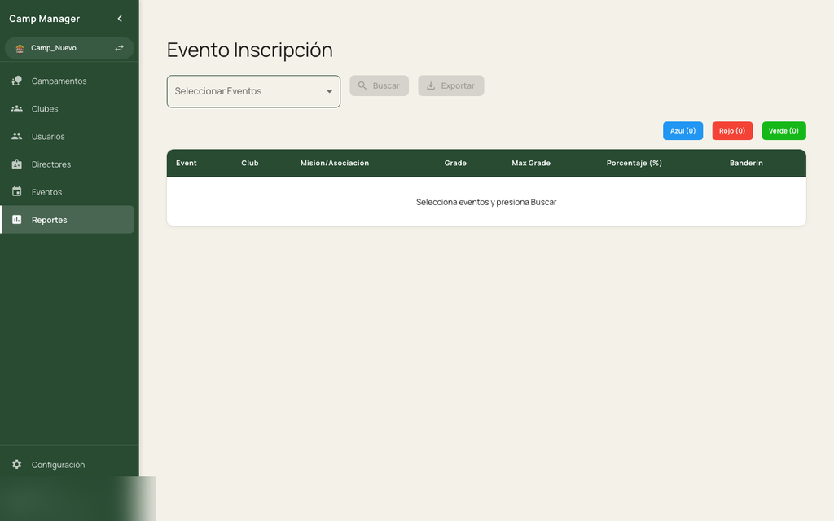

Reporte: Evento Inspección

## 7.6 Evento Calificados por Jueces

**Ruta:** `/reports/grades-confirmation-by-judges`

Auditoría de las calificaciones ingresadas por un juez específico en un evento.

### Filtros requeridos

1. **Evento** — selecciona el evento
2. **Juez** — selecciona el juez

La tabla muestra cada calificación ingresada: club, rúbrica, puntaje máximo, calificación, comentario y fecha/hora de registro. Los resultados se agrupan por club con subtotales.

**Tip**

Útil para verificar que un juez completó su asignación y para auditar cambios en calificaciones.

El botón **“Imprimir”** abre la vista de impresión del navegador.

## 7.7 Calificaciones por Evento

**Ruta:** `/reports/grades-by-events`

Ranking de clubes para un evento seleccionado, con desglose de rúbricas expandible.

### Filtro requerido

- **Evento** — selecciona el evento

### Qué muestra

- Posición, Club, Afiliación, Zona, Puntaje total
- Fila expandible (▼) con detalle de rúbricas: nombre, máx., calificación, evaluador, comentario, estado (✓ Calificado / ⚠ Pendiente)
- Métricas resumen: Total de clubes, Total de puntos, Promedio

El botón **“Imprimir”** abre la vista de impresión.

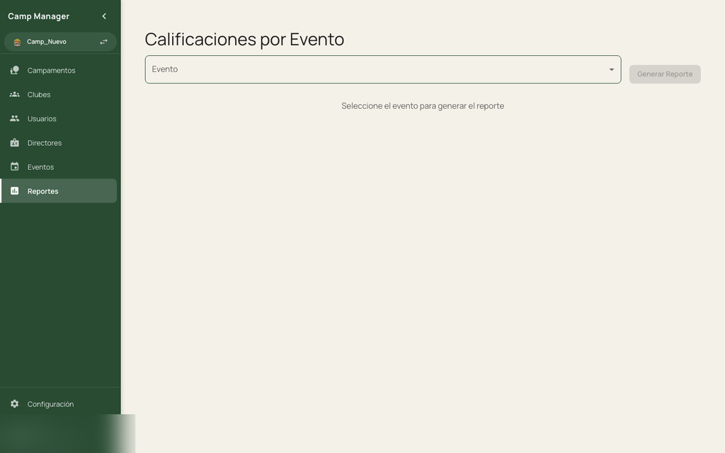

Reporte: Calificaciones por evento

## 7.8 Ranking por Campamento

**Ruta:** `/reports/ranking`

Clasificación final de todos los clubes del campamento basada en el puntaje total acumulado en todos los eventos.

1. Navega a la ruta
2. Haz clic en **“Generar Ranking”**
3. El sistema calcula y muestra la tabla con posición, club, director, puntos, porcentaje y clasificación

### Clasificación

Las categorías y sus umbrales de porcentaje se configuran al crear el campamento (ver sección 2. Campamentos). Ejemplo por defecto:

| Categoría | Desde |
| --- | --- |
| Excelencia | 90% |
| Honorable | 79% |
| Sobresaliente | 61% |
| Participación | 0% |

El botón **“Imprimir”** abre la vista de impresión con la leyenda de clasificación incluida.

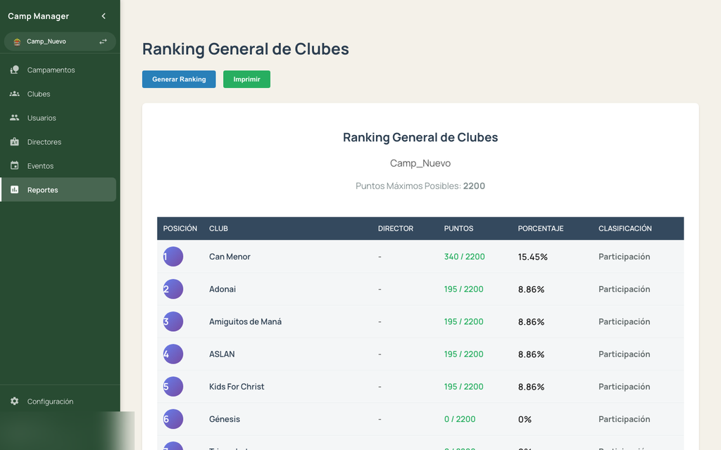

Reporte: Ranking

## 7.9 Calificaciones Pendientes

**Ruta:** `/reports/pending-grades`

Muestra el avance de calificación para un evento: cuántas rúbricas están calificadas y cuántas faltan por cada club.

### Filtros

- **Evento** *(obligatorio)* — selecciona el evento
- **Solo Pendientes** — toggle que filtra para mostrar únicamente los clubes con rúbricas sin calificar

### Qué muestra

- Club, Afiliación, Total de rúbricas, Calificadas, Pendientes, % completado con barra de progreso, Estado (Completo / Pendiente)
- Fila expandible (▼) con estado rúbrica a rúbrica
- Métricas resumen: Total clubes, Total rúbricas, Clubes completados, Clubes pendientes, Promedio de avance

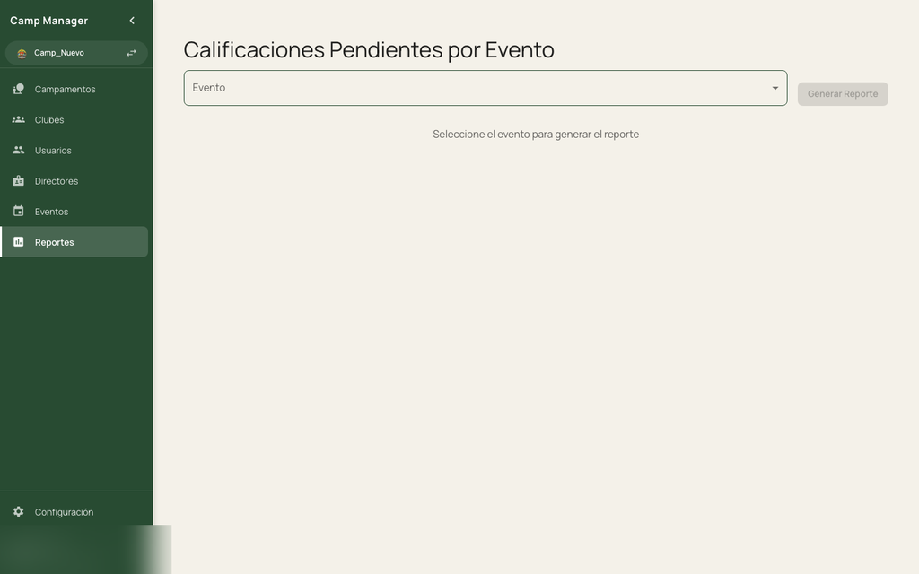

Reporte: Calificaciones pendientes

## 7.10 Rendimiento de Jueces

**Ruta:** `/reports/judge-performance`

Análisis de desempeño ponderado de cada juez en el campamento. Combina cuatro métricas en un puntaje único de 0 a 100.

### Métricas

| Componente | Descripción |
| --- | --- |
| **Calificaciones** | Cantidad y promedio de calificaciones ingresadas |
| **Estrellas Director** | Puntaje de 0-5 otorgado por el director del club (escala 0-100) |
| **Sentiment AI** | Análisis de sentimiento de los comentarios escritos por el juez |
| **Velocidad Sync** | Qué tan rápido sincronizó las calificaciones desde la app móvil |

Cada tarjeta de juez muestra el puntaje general, las barras de cada componente, y un desglose por evento (evento, promedio, cantidad de calificaciones, puntaje de sync).

### Filtro

- **Buscar** — filtra por nombre o nombre de usuario del juez (búsqueda en tiempo real)

El listado usa scroll infinito (10 jueces por página).

El botón **“Exportar PDF”** descarga el reporte del juez seleccionado.

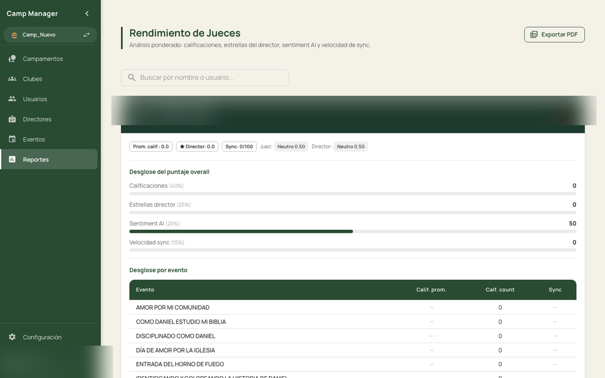

Reporte: Rendimiento de jueces

## 7.11 Performance de Eventos

**Ruta:** `/reports/event-performance`

Dashboard de rendimiento promedio por evento. Muestra qué eventos tienen calificaciones altas, medias o críticas.

### Sistema de semáforo

| Color | Rango |
| --- | --- |
| 🟢 Bueno | ≥ 80% |
| 🟡 Regular | ≥ 60% |
| 🔴 Crítico | < 60% |

Haz clic en una tarjeta de evento para ver el desglose: - **Por rúbrica** — promedio de calificación de cada rúbrica del evento - **Por club** — promedio de cada club con barra de progreso

### Recalcular

El botón **“Recalcular resultados”** actualiza los promedios con las calificaciones más recientes. Durante el proceso muestra “Calculando…”. La fecha/hora del último cálculo se muestra en pantalla.

**Nota**

Las métricas se calculan sobre los datos existentes al momento del último recálculo. Si se agregaron calificaciones nuevas, usa “Recalcular resultados” para actualizar.

# 8. Configuración

La sección **Configuración** (`/settings`) gestiona la estructura jerárquica de organizaciones y afiliaciones. Esta jerarquía define cómo se agrupan los clubes dentro de los campamentos.

## Jerarquía de conceptos

```
Organización  (nivel superior, se asigna al campamento)
    └── Afiliación  (sub-nivel, se asigna a cada club)
```

- Una **organización** es el nivel padre (ej. una unión, misión o región)
- Las **afiliaciones** son subdivisiones de esa organización (ej. zonas, distritos)
- Al crear un club, se selecciona una de las afiliaciones del campamento activo
- Los reportes agrupan resultados por afiliación/zona

## 8.1 Organizaciones

La pestaña **“Organizaciones”** muestra todas las organizaciones registradas en el sistema (independientes del campamento activo).

### Columnas

| Columna | Descripción |
| --- | --- |
| **Nombre** | Nombre de la organización |
| **Zona** | Zona opcional (puede estar vacía) |
| **Acciones** | Ícono de lápiz (editar) e ícono de papelera (eliminar) |

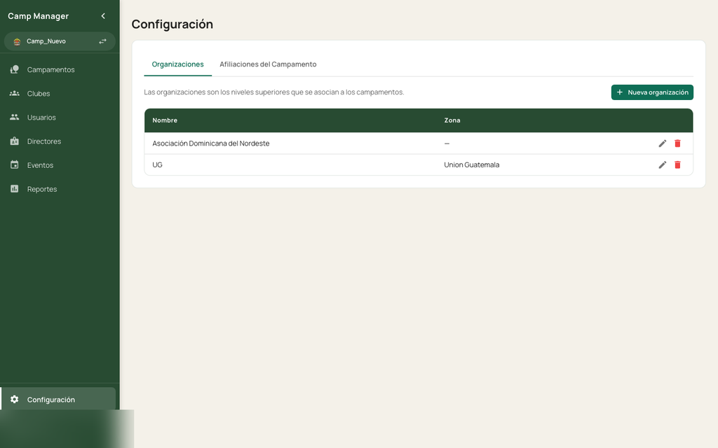

Lista de organizaciones

### Crear organización

1. Haz clic en **“Nueva organización”** (esquina superior derecha)
2. Completa los campos:
   - **Nombre** *(obligatorio)*
   - **Zona** *(opcional)*
3. Haz clic en **“Guardar”**

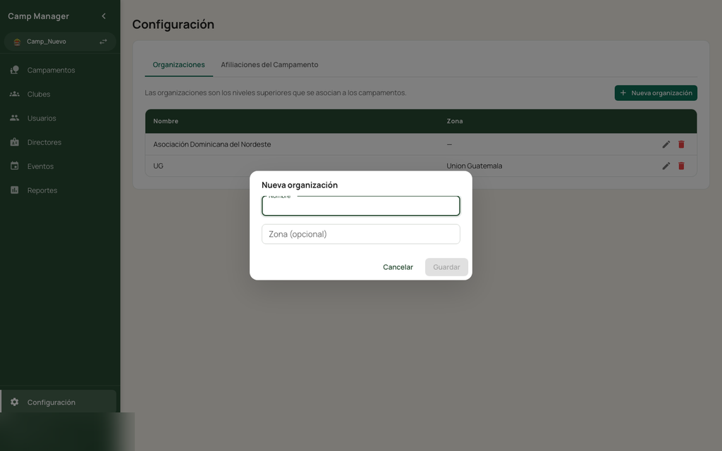

Formulario de organización

### Editar organización

1. En la fila de la organización, haz clic en el ícono de lápiz
2. Modifica los campos necesarios y haz clic en **“Guardar”**

### Eliminar organización

1. Haz clic en el ícono de papelera de la fila
2. Se abre un diálogo de confirmación
3. Haz clic en **“Confirmar”**

**Advertencia**

No es posible eliminar una organización si tiene afiliaciones hijas o clubes asociados. El sistema mostrará un mensaje de error en el diálogo si aplica.

## 8.2 Afiliaciones del Campamento

La pestaña **“Afiliaciones del Campamento”** muestra las afiliaciones vinculadas al campamento activo. **Solo estas afiliaciones aparecen en el selector al crear un club.**

**ImportanteRequisito previo**

El campamento activo debe tener una organización asignada. Si no la tiene, el sistema muestra un aviso y debes ir a Campamentos para editar el campamento y asignar una organización.

### Columnas

| Columna | Descripción |
| --- | --- |
| **Nombre** | Nombre de la afiliación |
| **Zona** | Zona opcional |
| **Acciones** | Editar y eliminar |

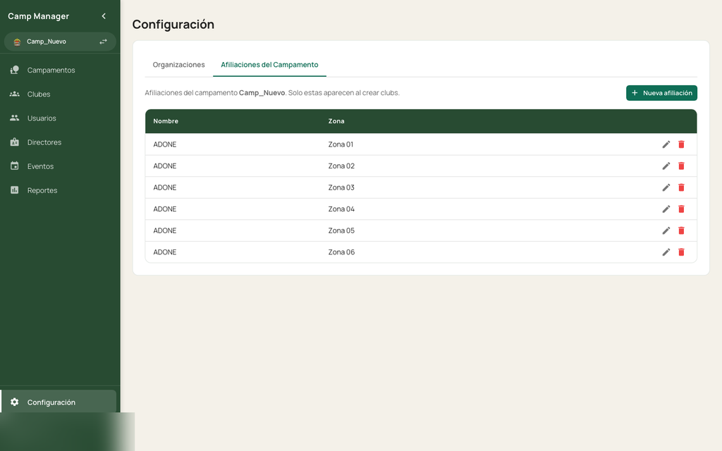

Lista de afiliaciones

### Crear afiliación

1. Haz clic en **“Nueva afiliación”** (esquina superior derecha)
2. Completa los campos:
   - **Nombre** *(obligatorio)*
   - **Zona** *(opcional)*
3. Haz clic en **“Guardar”**

La afiliación creada quedará disponible automáticamente al crear o editar clubes del campamento activo.

### Editar afiliación

1. Haz clic en el ícono de lápiz de la fila
2. Modifica los campos y haz clic en **“Guardar”**

### Eliminar afiliación

1. Haz clic en el ícono de papelera
2. Confirma en el diálogo

**Advertencia**

No es posible eliminar una afiliación si hay clubes asociados a ella.

## 8.3 Relación con otras secciones

| Sección | Cómo usa Configuración |
| --- | --- |
| **Campamentos** | Al crear o editar un campamento se asigna una **Organización** |
| **Clubes** | Al crear un club se selecciona una **Afiliación** de la lista del campamento activo |
| **Reportes** | Los reportes agrupan clubes y resultados por afiliación/zona |

# 9. Preguntas Frecuentes (FAQ)

## 9.1 Acceso y Cuenta

**¿Cómo inicio sesión en Camp Manager?**

Accede a https://campmanager.lirasprod.com/, ingresa tu usuario y contraseña en el formulario y haz clic en **Login**. El campo “Email” acepta el nombre de usuario.

**¿Qué hago si el sistema rechaza mis credenciales?**

Verifica que no haya errores de tipeo en usuario y contraseña. Si el error persiste, solicita a un administrador que resetee tu contraseña desde el módulo **Usuarios**. Al siguiente ingreso el sistema te pedirá definir una contraseña nueva.

**¿Por cuánto tiempo dura mi sesión activa?**

La sesión tiene una duración de **7 días**. Pasado ese tiempo el sistema redirige automáticamente a la pantalla de login para volver a autenticarse.

**¿Cómo cambio de campamento sin cerrar sesión?**

En la barra lateral izquierda, haz clic en el ícono de **flechas** (↔︎) junto al nombre del campamento activo. Se abrirá el diálogo “Seleccionar Campamento” para elegir otro sin interrumpir la sesión.

**¿Cómo cambio mi contraseña?**

Si es tu primer acceso o un administrador reseteó tu cuenta, el sistema te solicitará cambiar la contraseña al ingresar. Si deseas cambiarla en otro momento, pide a un administrador que reinicie tu contraseña desde **Usuarios → Resetear contraseña**.

**Nota**

El primer acceso siempre requiere cambio de contraseña; no se puede omitir este paso.

## 9.2 Campamentos

**¿Cómo creo un nuevo campamento?**

Ve al módulo **Campamentos** y haz clic en **+ Crear Campamento**. Completa nombre, fechas y demás campos del formulario, luego guarda. El nuevo campamento quedará disponible en el selector de campamento activo.

**¿Puedo editar el nombre o las fechas de un campamento después de crearlo?**

Sí. En la lista de campamentos, haz clic en el ícono de edición del campamento. Modifica los campos necesarios y guarda los cambios.

**¿Qué significa “publicar calificaciones” en un campamento?**

Publicar las calificaciones hace que los resultados sean visibles para los directores en su portal. Mientras las calificaciones no estén publicadas, los directores no pueden ver los puntajes de sus clubes.

**¿Puedo despublicar las calificaciones después de haberlas publicado?**

Sí, la acción de publicar/despublicar es reversible. Desde la vista del campamento puedes alternar el estado en cualquier momento.

**Advertencia**

Despublicar oculta los resultados inmediatamente para todos los directores del campamento activo.

**¿Cómo subo o cambio el logo de un campamento?**

Abre el campamento en modo edición y busca el campo de logo. Selecciona un archivo de imagen desde tu equipo y guarda. El logo aparecerá en los reportes y en la cabecera del portal de directores.

## 9.3 Clubes

**¿Cómo agrego un nuevo club al campamento activo?**

Ve al módulo **Clubes** y haz clic en **+ Agregar Club**. Ingresa el nombre del club y los demás datos requeridos. El club queda vinculado automáticamente al campamento activo seleccionado.

**¿Puedo importar múltiples clubes a la vez desde Excel?**

Sí. En el módulo **Clubes** utiliza la opción **Importar** y sube un archivo `.xlsx` o `.csv`. El sistema mostrará un asistente de mapeo de columnas para asociar los encabezados de tu archivo con los campos del sistema.

**Tip**

Descarga la plantilla de ejemplo antes de preparar tu archivo para asegurarte de incluir todas las columnas requeridas.

**¿Qué columnas se requieren en el archivo de importación de clubes?**

Como mínimo se requiere el **nombre del club**. Columnas opcionales incluyen número, afiliación y zona. El asistente de mapeo acepta variantes comunes de nombres de columna (por ejemplo `club`, `nombre`, `name`).

**¿Cómo elimino un club del campamento?**

En la lista de clubes, haz clic en el ícono de eliminar del club correspondiente. El sistema aplicará un borrado lógico (soft-delete); el club no aparecerá en listas ni reportes pero sus datos históricos se conservan.

## 9.4 Usuarios

**¿Cómo invito a un nuevo juez o administrador al sistema?**

Ve al módulo **Usuarios** y haz clic en **Invitar Usuario**. Ingresa el correo electrónico y selecciona el rol. El usuario recibirá un correo con sus credenciales de primer acceso.

**¿Cómo reseteo la contraseña de un usuario?**

En la lista de usuarios, localiza al usuario y usa la opción **Resetear contraseña**. El sistema generará una contraseña temporal y marcará la cuenta con `firstTime: true`, de modo que el usuario deberá cambiarla en su próximo ingreso.

**¿Qué roles existen en Camp Manager?**

Los roles principales son **Administrador** (acceso total al panel web) y **Juez** (acceso a la app móvil para calificar). Los directores tienen acceso exclusivo a su portal y se gestionan desde el módulo **Directores**.

**¿Puedo eliminar un usuario del sistema?**

El módulo de usuarios permite desactivar cuentas. Consulta con el administrador del sistema si necesitas una eliminación permanente, ya que los registros de calificaciones están vinculados al usuario.

**Importante**

Eliminar permanentemente un usuario puede afectar el historial de calificaciones registradas con su cuenta.

## 9.5 Directores

**¿Cómo invito a un director al portal?**

Ve al módulo **Directores** y usa la opción **Invitar Director**. Ingresa el correo electrónico y asóciale un club. El director recibirá acceso al portal donde podrá consultar los resultados de su club.

**¿Qué puede ver y hacer un director en su portal?**

Un director puede ver las calificaciones y reportes del club que tiene asignado, una vez que el administrador haya publicado las calificaciones del campamento. No tiene acceso al panel de administración.

**¿Puedo importar múltiples directores a la vez?**

Sí. Desde el módulo **Directores** utiliza la opción de importación masiva. El proceso es similar al de clubes: sube un archivo `.xlsx` o `.csv` y mapea las columnas en el asistente.

**Tip**

Asegúrate de que los clubes ya estén creados antes de importar directores, ya que la importación puede vincular directores a clubes existentes.

## 9.6 Eventos y Rúbricas

**¿Cómo creo un nuevo evento?**

Ve al módulo **Eventos** y haz clic en **+ Nuevo Evento**. Selecciona el tipo de evento, asigna un nombre y configura los parámetros necesarios. Los eventos quedan vinculados al campamento activo.

**¿Cómo asigno jueces a un evento?**

Dentro de un evento, accede a la sección de asignación de jueces. Selecciona los usuarios con rol **Juez** que participarán en la evaluación. Los jueces verán el evento en su aplicación móvil.

**¿Cómo quito un juez de una rúbrica específica?**

Expande el evento en la sección **Eventos**, luego haz clic en el botón ⋮ de la rúbrica y selecciona **“Editar jueces”**. En el diálogo, haz clic en el ícono de papelera del juez que deseas remover (la fila se marcará en rojo con texto tachado) y presiona **“Guardar”** para confirmar. Si cambias de opinión antes de guardar, usa el botón “Deshacer” de esa fila.

También puedes desasignarlo desde **Usuarios**: expande la fila del juez, ubica la rúbrica (usa el filtro por evento si tiene varias) y haz clic en el ícono de papelera.

**¿Qué es una rúbrica y cómo se configura?**

Una rúbrica define los criterios de evaluación y sus ponderaciones para un evento. Se configura desde la sección **Rúbricas** dentro del evento: agrega los criterios, asigna puntajes máximos y define categorías de calificación.

**¿Puedo modificar una rúbrica después de que los jueces ya hayan calificado?**

Se puede editar la rúbrica, pero cualquier cambio en ponderaciones o criterios afectará los cálculos de calificaciones ya registradas.

**Advertencia**

Modificar una rúbrica con calificaciones existentes puede alterar los reportes y rankings. Se recomienda hacerlo solo antes de iniciar la evaluación o en coordinación con todos los evaluadores.

## 9.7 Reportes

**¿Cómo accedo a los reportes del campamento?**

Ve al módulo **Reportes** en la barra lateral. Los reportes disponibles se muestran en un menú de dashboards. Todos los reportes corresponden al campamento activo seleccionado.

**¿Puedo exportar o imprimir un reporte?**

Sí. Desde la vista de cualquier reporte utiliza la opción de impresión del navegador (`Ctrl + P` / `Cmd + P`) o el botón de exportar si está disponible en ese reporte. El diseño está optimizado para impresión.

**¿Los reportes se actualizan en tiempo real?**

Los reportes reflejan los datos al momento de cargar la página. Para obtener los resultados más recientes, recarga el reporte. No hay actualización automática en segundo plano.

## 9.8 Configuración

**¿Cómo configuro una nueva organización?**

Ve al módulo **Configuración** y selecciona la sección **Organizaciones**. Haz clic en **+ Nueva Organización**, completa el nombre y los datos requeridos, y guarda. Las organizaciones agrupan afiliaciones y zonas dentro del sistema.

**¿Qué son las afiliaciones o zonas y cómo se usan?**

Las afiliaciones (también llamadas zonas) son subdivisiones dentro de una organización que permiten agrupar clubes por región o distrito. Se asignan a los clubes al momento de crearlos o editarlos, y pueden usarse como filtro en los reportes.

**¿Puedo tener múltiples organizaciones en el sistema?**

Sí. El sistema admite múltiples organizaciones, cada una con sus propias afiliaciones. Cada campamento puede estar asociado a una organización específica.

**Nota**

La configuración de organizaciones es global; afecta a todos los campamentos del sistema, no solo al campamento activo.

*© Todos los derechos reservados Lira’s Prod 2026*